# Herramientas y Tutoriales

Tutoriales paso a paso y herramientas para trabajar con señales, imágenes y Quarto.

Tutoriales cortos y herramientas que acompañan los cursos y los proyectos. Usa las categorías de la derecha para filtrar: **Tutorial** o **Herramienta**, el curso (PSIM, SYSB, TAU) o el tema.

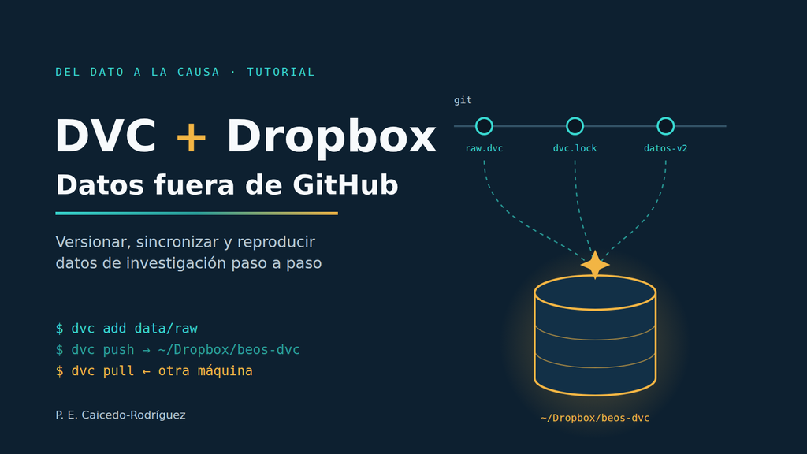

##### Datos fuera de GitHub con DVC y Dropbox

desarrollo

datos

herramientas

24 oct 2026

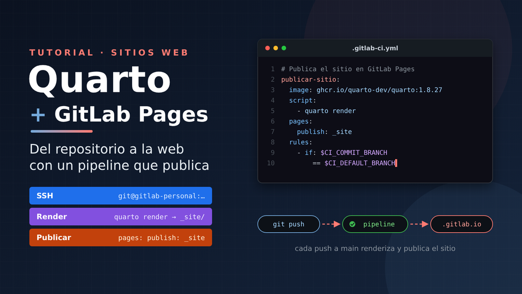

##### Un sitio Quarto en GitLab Pages

desarrollo

herramientas

24 oct 2026

[figure not shown]

##### Validación cruzada por participante

Tutorial

TAU

Aprendizaje automático

Cuando cada persona aporta varios ensayos, repartir ensayos entre entrenamiento y prueba infla la exactitud. Cómo evitarlo con GroupKFold.

14 oct 2026

[figure not shown]

##### Filtrado de fase cero en un ECG

Tutorial

SYSB

Señales

Por qué lfilter retrasa la onda R y filtfilt no, y cuándo conviene cada uno.

5 oct 2026

[figure not shown]

##### Filtros en frecuencia: de Ideal a Gaussiano

Tutorial

PSIM

Imágenes médicas

Transformada de Fourier 2D, la distancia D(u, v) en ciclos por píxel y tres pasa bajos con la misma frecuencia de corte, implementados en NumPy.

21 sep 2026

##### Entorno reproducible con uv y Quarto

Herramienta

PSIM

SYSB

TAU

Quarto

Instalar Python, las bibliotecas del curso y Quarto de forma que el mismo código corra igual en cualquier equipo.

3 ago 2026